# MIAmaxent — variable transformation and model selection for species distribution models

Julien Vollering

November 11, 2021

# Background for the package

## Maxent software (maxent.jar)

1. variable transformation
2. maximum entropy fitting
3. lasso regularization

## Many users keep default:

- variable transformation types
- regularization strength

leads to **overfitted models**

- output format (logistic or cloglog)

easily **misinterpreted**

## MIAmaxent’s approach

1. variable transformation based on expected occurrence-environment relationships
2. choice of maximum entropy or logistic regression fitting
3. model selection by forward stepwise selection

**decoupled**

## Motivation

To improve on the success of the Maxent software by creating tools that produce more **interpretable and ecologically-grounded** models.

Especially suited to **explain occurrence-environment** relationships, and to make predictions **outside the time and/or space** of the training data.

A model selected by MIAmaxent (open) and one selected by maxnet (solid), both tuned to optimal complexity…

[figure not shown]

## A word of caution on stepwise selection

- p-values too low, CIs too narrow, etc, owing to multiple testing
- struggles with collinear predictors
- performs poorly when N:P ratio is low
- undue emphasis on a single model

My recommendations with regard to MIAmaxent:

- don’t treat p-values at face value
- include known influences regardless of explanatory power (with `formula`)
- use the threshold criterion `alpha` as a complexity penalty that needs tuning

## MIAmaxent doesn’t help you with:

- study area selection
- data cleaning
- sampling bias correction
- (among other considerations)

Other distribution modeling packages:

*dismo*, *biomod2*, *sdm*, *zoon*, *wallace*, *ENMTools*, *spThin*, *ENMeval*, *SDMtune*…

# Package functionality (v.1.2.0)

## Some terms

*top-level function*

*argument*

*occurrence data*

*explanatory variable (EV)* vs. *derived variable (DV)*

*training data* vs. *test data*

## Implementation

Fully implemented in R, uses `glm()` function internally for model fitting

(avoids Java dependency)

## Workflow

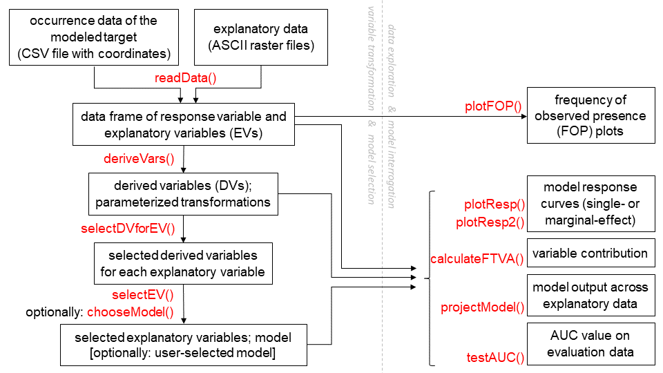

# Demonstration data set

## Presence-only occurrence data

```r
PO <- read_csv("simdata/presences.csv")
PO
```

```
## # A tibble: 41 x 3
##    Occurrence xcoord ycoord
##    <chr>       <dbl>  <dbl>
##  1 sp.           0.5    0.5
##  2 sp.           0.5    1.5
##  3 sp.           0.5    2.5
##  4 sp.           0.5    3.5
##  5 sp.           1.5    0.5
##  6 sp.           1.5    1.5
##  7 sp.           1.5    2.5
##  8 sp.           1.5    4.5
##  9 sp.           1.5    7.5
## 10 sp.           2.5    0.5
## # ... with 31 more rows
```

## Presences

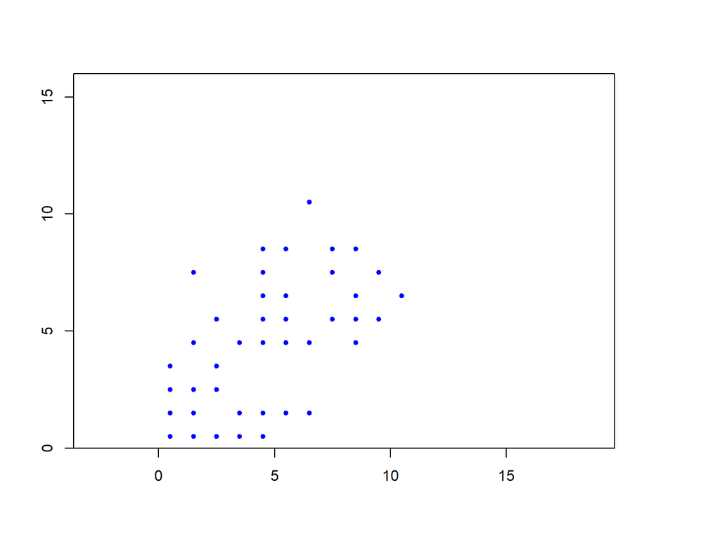

## Continuous EV: “northing”

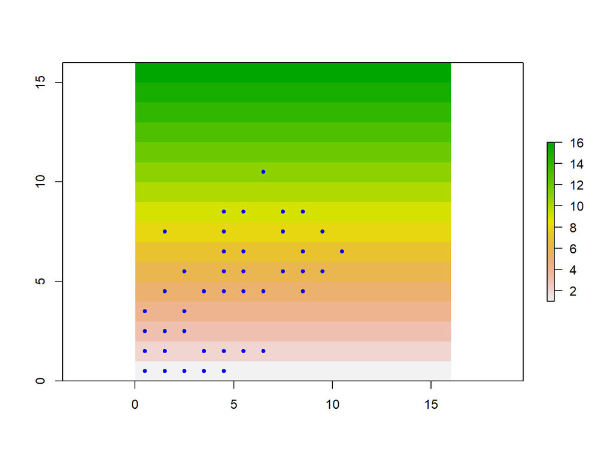

## Continuous EV: “easting”

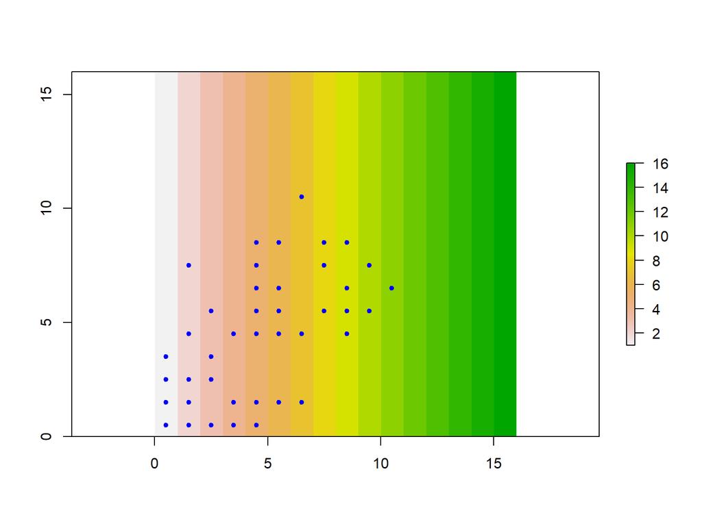

## Continuous EV: “SWblocks”

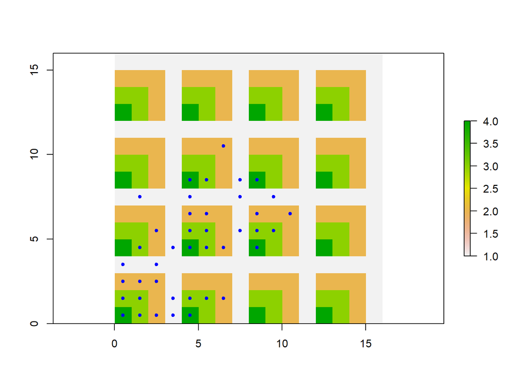

## Continuous EV: “random”

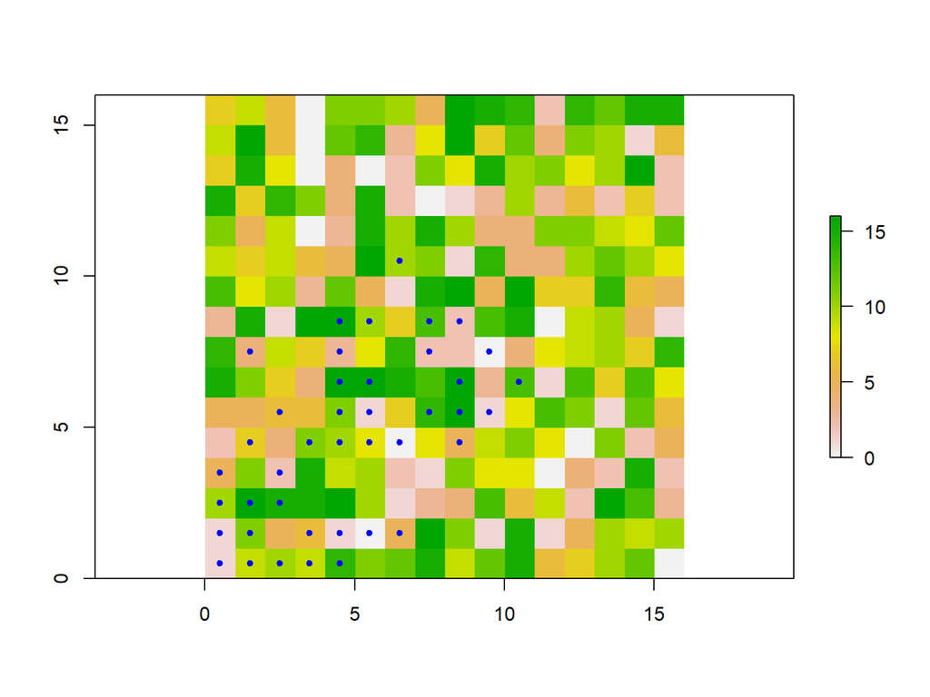

## Categorical EV: “diagonal”

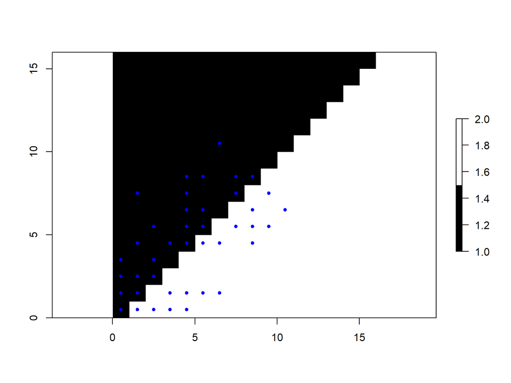

# `readData()`

makes it easy to read in data from CSV and ASCII raster files

**Arguments:**

*occurrence*, *contEV*, *catEV* — file pathways to the data

*maxbkg* — maximum number of background cells

*PA* — presence-absence or presence-only?

*XY* — include coordinates?

## `readData()`

```r
library(MIAmaxent)
dat <- readData(occurrence = "simdata/presences.csv",
                contEV = "simdata/continuous/",
                catEV = "simdata/categorical/",
                PA = FALSE)
str(dat)
```

```
## 'data.frame':    256 obs. of  6 variables:
##  $ RV      : num  1 1 1 1 1 1 1 1 1 1 ...
##  $ easting : num  1 1 1 1 2 2 2 2 2 3 ...
##  $ northing: num  1 2 3 4 1 2 3 5 8 1 ...
##  $ random  : num  1 1 10 5 9 11 16 7 4 10 ...
##  $ SWblocks: num  4 3 2 1 3 3 2 3 1 2 ...
##  $ diagonal: Factor w/ 2 levels "1","2": 1 1 1 1 2 1 1 1 1 2 ...
```

# `plotFOP()`

plots rate of occurrence across intervals or levels of a given EV

**Arguments:**

*data* — data frame containing the response and explanatory variables

*EV* — the name of the EV of interest

*intervals* — number of intervals (points on the plot)

*…*

## `plotFOP()`

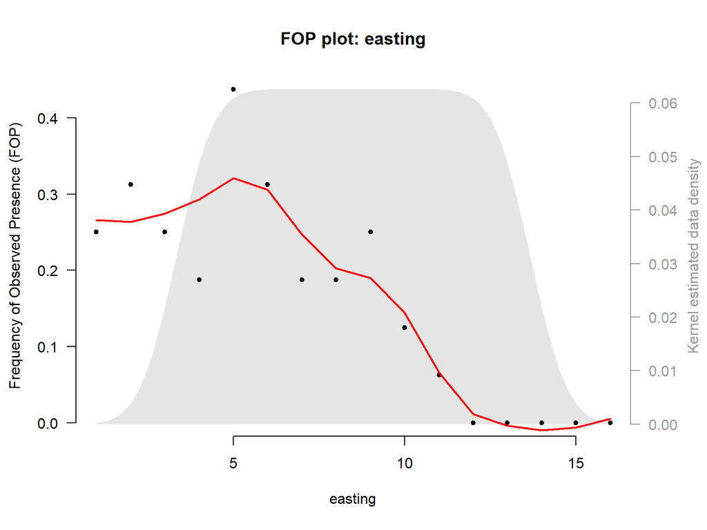

```r
easting <- plotFOP(dat, "easting")
```

## `plotFOP()`

```r
easting
```

```
## $EVoptimum
## [1] 5
##
## $FOPdata
##             int  n intEV  intRV        loess
## 1  (0.985,1.58] 16     1 0.2500  0.266189344
## 2   (1.58,2.15] 16     2 0.3125  0.263551137
## 3   (2.73,3.31] 16     3 0.2500  0.274623197
## 4   (3.88,4.46] 16     4 0.1875  0.292976777
## 5   (4.46,5.04] 16     5 0.4375  0.320822805
## 6   (5.62,6.19] 16     6 0.3125  0.305690734
## 7   (6.77,7.35] 16     7 0.1875  0.246906723
## 8    (7.92,8.5] 16     8 0.1875  0.202668776
## 9    (8.5,9.08] 16     9 0.2500  0.189888621
## 10  (9.65,10.2] 16    10 0.1250  0.144137134
## 11  (10.8,11.4] 16    11 0.0625  0.065904633
## 12    (12,12.5] 16    12 0.0000  0.011341349
## 13  (12.5,13.1] 16    13 0.0000 -0.003827427
## 14  (13.7,14.3] 16    14 0.0000 -0.009520462
## 15  (14.8,15.4] 16    15 0.0000 -0.006276775
## 16    (15.4,16] 16    16 0.0000  0.005433797
```

# `deriveVars()`

creates derived variables from explanatory variables by a set of transformation types: linear, monotone, deviation, hinge, threshold, binary

**Arguments:**

*data* — data frame containing the response and explanatory variables

*transformtype* — which transformation types?

*…*

## `deriveVars()`

```r
der <- deriveVars(dat, transformtype = c("L", "M", "D", "T", "B"), quiet = TRUE)
str(der)
```

```
## List of 2
##  $ dvdata         :List of 6
##   ..$ RV      : num [1:256] 1 1 1 1 1 1 1 1 1 1 ...
##   ..$ easting :'data.frame': 256 obs. of  7 variables:
##   .. ..$ easting_L  : num [1:256] 0 0 0 0 0.0667 ...
##   .. ..$ easting_M  : num [1:256] 0 0 0 0 0.0694 ...
##   .. ..$ easting_D05: num [1:256] 0.603 0.603 0.603 0.603 0.522 ...
##   .. ..$ easting_D1 : num [1:256] 0.364 0.364 0.364 0.364 0.273 ...
##   .. ..$ easting_D2 : num [1:256] 0.1322 0.1322 0.1322 0.1322 0.0744 ...
##   .. ..$ easting_T14: num [1:256] 0 0 0 0 0 0 0 0 0 0 ...
##   .. ..$ easting_T15: num [1:256] 0 0 0 0 0 0 0 0 0 0 ...
##   ..$ northing:'data.frame': 256 obs. of  8 variables:
##   .. ..$ northing_L  : num [1:256] 0 0.0667 0.1333 0.2 0 ...
##   .. ..$ northing_M  : num [1:256] 0 0.0694 0.1385 0.2071 0 ...
##   .. ..$ northing_D05: num [1:256] 0 0.258 0.365 0.447 0 ...
##   .. ..$ northing_D1 : num [1:256] 0 0.0667 0.1333 0.2 0 ...
##   .. ..$ northing_D2 : num [1:256] 0 0.00444 0.01778 0.04 0 ...
##   .. ..$ northing_T3 : num [1:256] 0 0 1 1 0 0 1 1 1 0 ...
##   .. ..$ northing_T12: num [1:256] 0 0 0 0 0 0 0 0 0 0 ...
##   .. ..$ northing_T15: num [1:256] 0 0 0 0 0 0 0 0 0 0 ...
##   ..$ random  :'data.frame': 256 obs. of  5 variables:
##   .. ..$ random_L  : num [1:256] 0.0625 0.0625 0.625 0.3125 0.5625 ...
##   .. ..$ random_M  : num [1:256] 0.0585 0.0585 0.6087 0.2978 0.5455 ...
##   .. ..$ random_D05: num [1:256] 0.968 0.968 0.612 0.829 0.661 ...
##   .. ..$ random_D1 : num [1:256] 0.938 0.938 0.375 0.688 0.438 ...
##   .. ..$ random_D2 : num [1:256] 0.879 0.879 0.141 0.473 0.191 ...
##   ..$ SWblocks:'data.frame': 256 obs. of  14 variables:
##   .. ..$ SWblocks_L  : num [1:256] 1 0.667 0.333 0 0.667 ...
##   .. ..$ SWblocks_M  : num [1:256] 1 0.849 0.61 0 0.849 ...
##   .. ..$ SWblocks_D05: num [1:256] 0 0.577 0.816 1 0.577 ...
##   .. ..$ SWblocks_D1 : num [1:256] 0 0.333 0.667 1 0.333 ...
##   .. ..$ SWblocks_D2 : num [1:256] 0 0.111 0.444 1 0.111 ...
##   .. ..$ SWblocks_T3 : num [1:256] 1 1 1 0 1 1 1 1 0 1 ...
##   .. ..$ SWblocks_T4 : num [1:256] 1 1 1 0 1 1 1 1 0 1 ...
##   .. ..$ SWblocks_T5 : num [1:256] 1 1 1 0 1 1 1 1 0 1 ...
##   .. ..$ SWblocks_T8 : num [1:256] 1 1 0 0 1 1 0 1 0 0 ...
##   .. ..$ SWblocks_T9 : num [1:256] 1 1 0 0 1 1 0 1 0 0 ...
##   .. ..$ SWblocks_T10: num [1:256] 1 1 0 0 1 1 0 1 0 0 ...
##   .. ..$ SWblocks_T11: num [1:256] 1 1 0 0 1 1 0 1 0 0 ...
##   .. ..$ SWblocks_T12: num [1:256] 1 1 0 0 1 1 0 1 0 0 ...
```

[output cut: 27 more lines]

```
##   ..$ SWblocks_M_transf  :function (x)
##   ..$ SWblocks_D05_transf:function (x)
##   ..$ SWblocks_D1_transf :function (x)
##   ..$ SWblocks_D2_transf :function (x)
##   ..$ SWblocks_T3_transf :function (x)
##   ..$ SWblocks_T4_transf :function (x)
##   ..$ SWblocks_T5_transf :function (x)
##   ..$ SWblocks_T8_transf :function (x)
##   ..$ SWblocks_T9_transf :function (x)
##   ..$ SWblocks_T10_transf:function (x)
##   ..$ SWblocks_T11_transf:function (x)
##   ..$ SWblocks_T12_transf:function (x)
##   ..$ SWblocks_T13_transf:function (x)
##   ..$ diagonal_BX1_transf:function (x)
##   ..$ diagonal_BX2_transf:function (x)
```

## `deriveVars()`

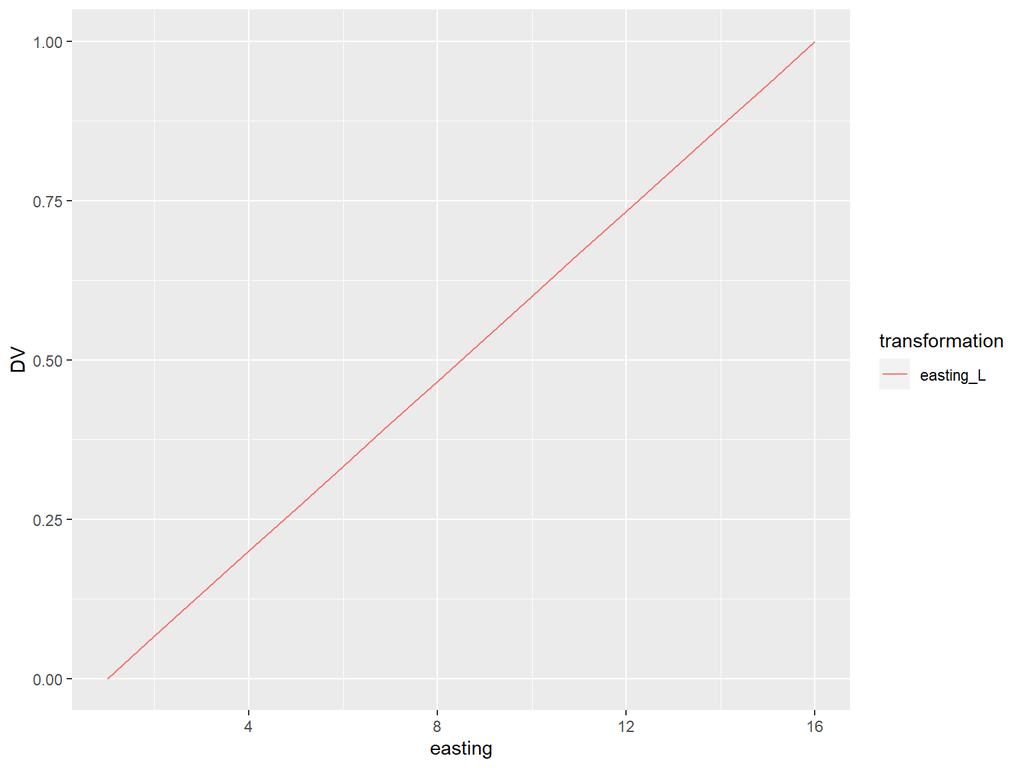

## `deriveVars()`

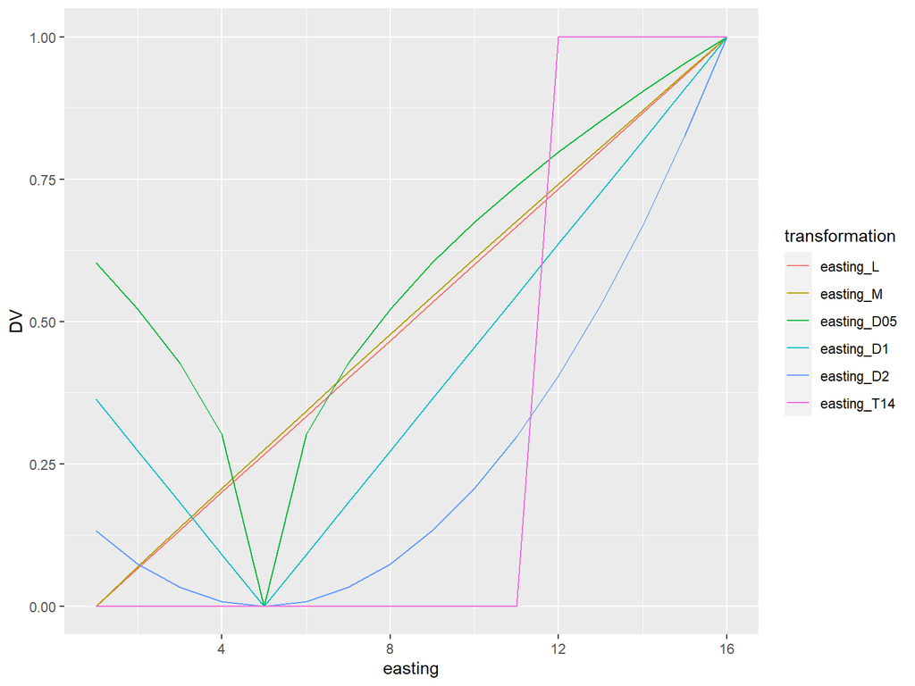

# `selectDVforEV()`

selects the parsimonious set of DVs which best explains occurrence, separately for each EV

**Arguments:**

*dvdata* — list of response variable followed by data frames of DVs

*alpha* — significance level used in nested model comparison tests (e.g. 0.01)

*…*

## `selectDVforEV()`

```r
selder <- selectDVforEV(der$dvdata, alpha = 0.01, quiet = TRUE)
str(selder, 2)
```

```
## List of 2
##  $ dvdata   :List of 4
##   ..$ RV      : num [1:256] 1 1 1 1 1 1 1 1 1 1 ...
##   ..$ easting :'data.frame': 256 obs. of  1 variable:
##   ..$ northing:'data.frame': 256 obs. of  1 variable:
##   ..$ SWblocks:'data.frame': 256 obs. of  1 variable:
##  $ selection:List of 5
##   ..$ easting :'data.frame': 13 obs. of  7 variables:
##   ..$ northing:'data.frame': 14 obs. of  7 variables:
##   ..$ random  :'data.frame': 5 obs. of  7 variables:
##   ..$ SWblocks:'data.frame': 24 obs. of  7 variables:
##   ..$ diagonal:'data.frame': 2 obs. of  7 variables:
```

## `selectDVforEV()`

```r
selder$selection$easting
```

```
##    round                variables m   Dsq  Chisq df        P
## 1      1               easting_D2 1 0.052 31.900  1 1.62e-08
## 2      1              easting_T14 1 0.050 30.695  1 3.02e-08
## 3      1              easting_T15 1 0.050 30.695  1 3.02e-08
## 4      1               easting_D1 1 0.045 27.556  1 1.53e-07
## 5      1              easting_D05 1 0.036 21.756  1 3.10e-06
## 6      1                easting_L 1 0.035 21.587  1 3.38e-06
## 7      1                easting_M 1 0.035 21.287  1 3.95e-06
## 8      2 easting_D2 + easting_T14 2 0.057  2.667  1 1.02e-01
## 9      2 easting_D2 + easting_T15 2 0.057  2.667  1 1.02e-01
## 10     2   easting_D2 + easting_L 2 0.053  0.504  1 4.78e-01
## 11     2   easting_D2 + easting_M 2 0.053  0.504  1 4.78e-01
## 12     2  easting_D2 + easting_D1 2 0.053  0.386  1 5.34e-01
## 13     2 easting_D2 + easting_D05 2 0.052  0.003  1 9.56e-01
```

# `selectEV()`

selects the parsimonious set of EVs which best explains occurrence.

Each EV is represented by one or more derived variables.

**Arguments:**

*dvdata* — list of response variable followed by data frames of DVs

*alpha* — significance level used in nested model comparison tests (e.g. 0.01)

*interaction* — test interaction terms between pairs of EVs?

*formula* — include any EVs *a priori*?

*…*

## `selectEV()`

```r
selexp <- selectEV(selder$dvdata, alpha = 0.01, interaction=FALSE, quiet = TRUE)
str(selexp, 1)
```

```
## List of 3
##  $ dvdata       :List of 3
##  $ selection    :'data.frame':   5 obs. of  7 variables:
##  $ selectedmodel:List of 34
##   ..- attr(*, "class")= chr [1:3] "iwlr" "glm" "lm"
```

```r
selexp$selection
```

```
##   round           variables m   Dsq  Chisq df        P
## 1     1            northing 1 0.063 38.234  1 6.27e-10
## 2     1             easting 1 0.052 31.900  1 1.62e-08
## 3     1            SWblocks 1 0.014  8.530  1 3.49e-03
## 4     2  northing + easting 2 0.115 31.877  1 1.64e-08
## 5     2 northing + SWblocks 2 0.072  5.786  1 1.62e-02
```

# `plotResp()`

plots the model response across a given EV in the model

**Arguments:**

*model* — model object

*transformations* — transformation functions used to create the DVs

*EV* — the name of the EV of interest

*…*

## `plotResp()`

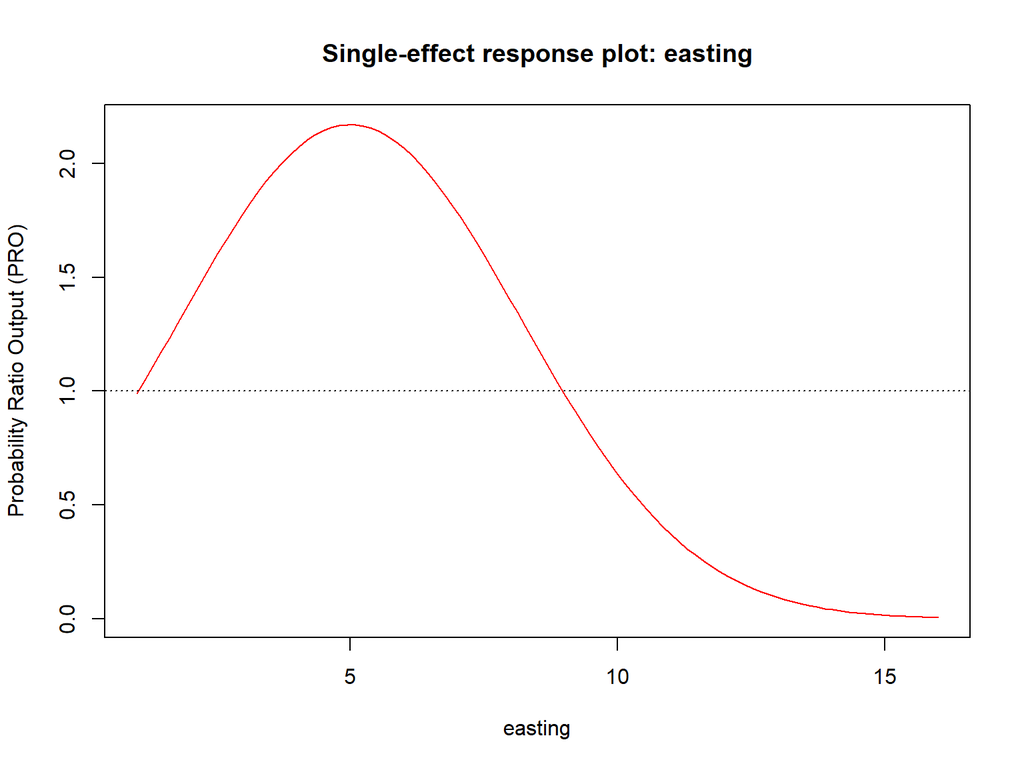

```r
plotResp(selexp$selectedmodel, der$transformations, "easting")
```

# `projectModel()`

calculates model predictions across any values of EVs.

**Arguments:**

*model* — model object

*transformations* — transformation functions used to create the DVs

*data* — values for all EVs in the model, as data frame or RasterStack

*clamping* — restrict values to the interval in the training data?

*…*

## `projectModel()`

```r
ras <- stack("simdata/continuous/easting.asc", "simdata/continuous/northing.asc")
pred <- projectModel(selexp$selectedmodel, der$transformations, ras)
```

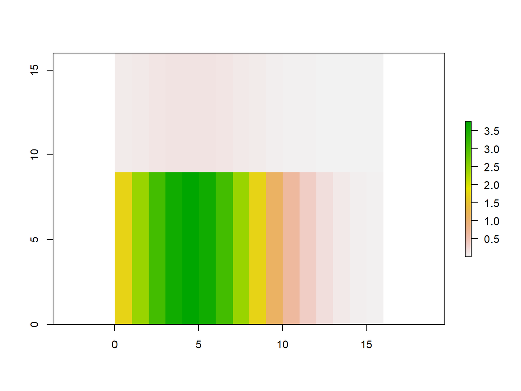

```r
calculateFTVA(selexp)
```

```
##   variable  FTVA
## 1 northing 0.548
## 2  easting 0.452
```

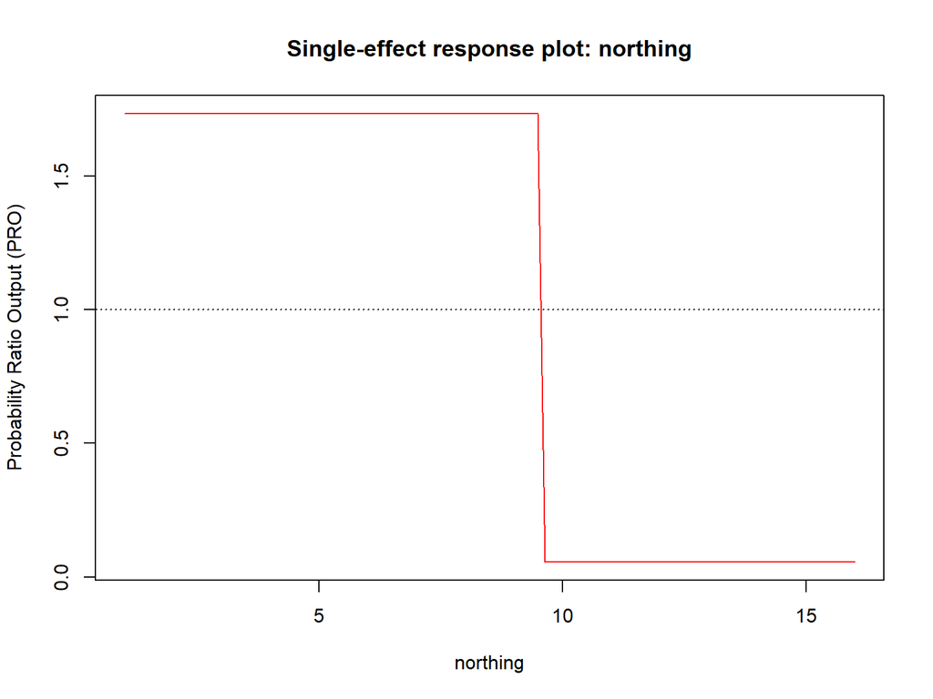

```r
plotResp(selexp$selectedmodel, der$transformations, "northing")
```

```r
selder$selection$northing
```

```
##    round                   variables m   Dsq  Chisq df        P
## 1      1                northing_T12 1 0.063 38.234  1 6.27e-10
## 2      1                 northing_D2 1 0.052 31.610  1 1.88e-08
## 3      1                northing_T15 1 0.050 30.695  1 3.02e-08
## 4      1                  northing_L 1 0.040 24.434  1 7.69e-07
## 5      1                 northing_D1 1 0.040 24.434  1 7.69e-07
## 6      1                  northing_M 1 0.040 24.127  1 9.02e-07
## 7      1                northing_D05 1 0.028 17.095  1 3.55e-05
## 8      1                 northing_T3 1 0.010  6.060  1 1.38e-02
## 9      2 northing_T12 + northing_T15 2 0.067  2.505  1 1.13e-01
## 10     2  northing_T12 + northing_D2 2 0.063  0.289  1 5.91e-01
## 11     2   northing_T12 + northing_L 2 0.063  0.133  1 7.15e-01
## 12     2  northing_T12 + northing_D1 2 0.063  0.133  1 7.15e-01
## 13     2   northing_T12 + northing_M 2 0.063  0.129  1 7.19e-01
## 14     2 northing_T12 + northing_D05 2 0.063  0.129  1 7.20e-01
```

# `testAUC()`

calculates AUC from provided test data

For an unbiased measure of model performance, best used with independently collected presence-absence data.

**Arguments:**

*model* — model object

*transformations* — transformation functions used to create the DVs

*data* — data frame containing the response and explanatory variables

*…*

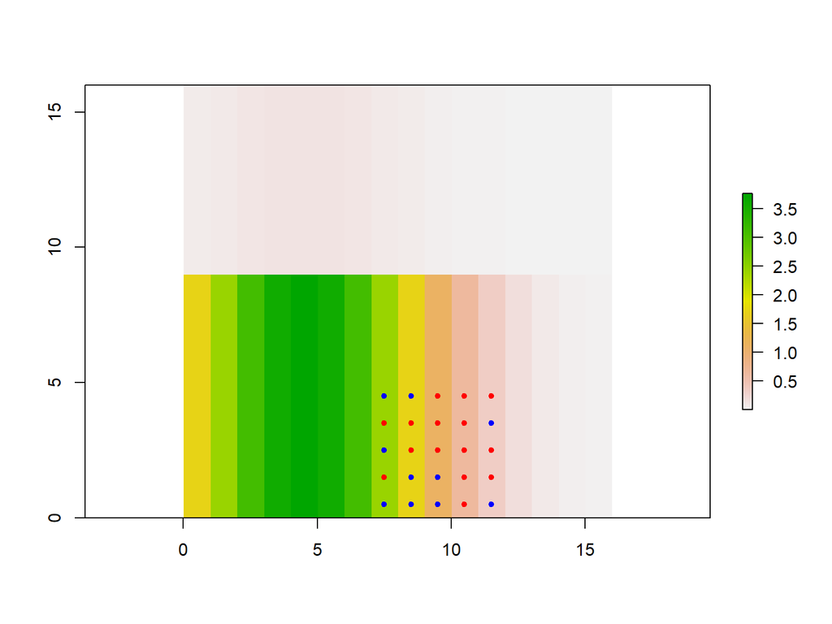

```r
PAdat <- readData(occurrence = "simdata/presence-absence.csv",
                  contEV = "simdata/continuous/",
                  catEV = "simdata/categorical/",
                  PA = TRUE, XY = TRUE)
plot(pred$output)
points(PAdat$x, PAdat$y, pch=20, col=c("red", "blue")[PAdat$RV+1])
```

## `testAUC()`

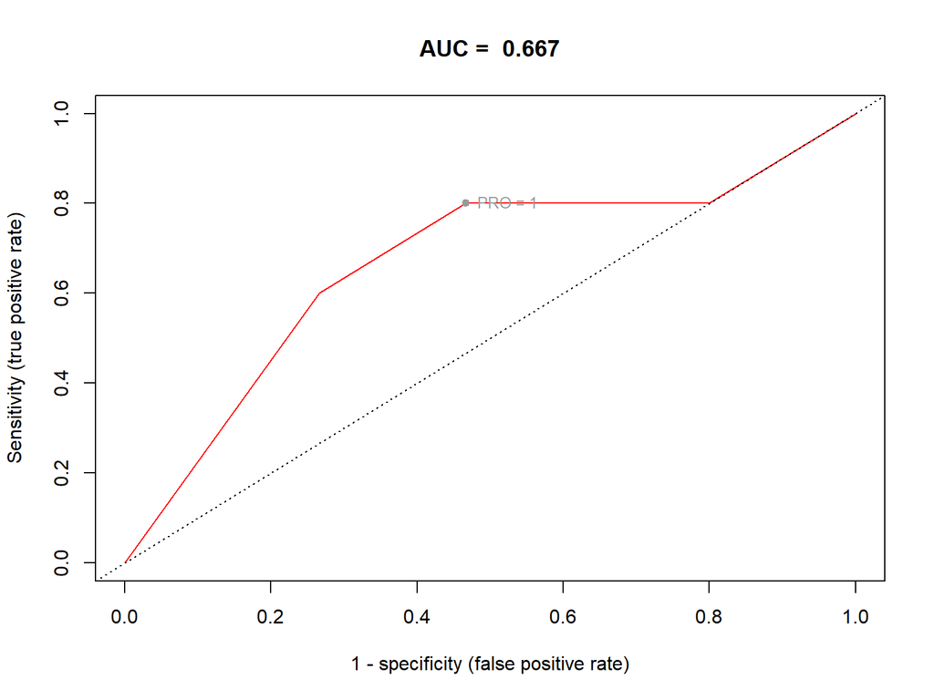

```
## [1] 0.6666667
```

```r
testAUC(selexp$selectedmodel, der$transformations, PAdat)
```

# Logistic regression

## Logistic regression

Choose between maximum entropy model fitting and logistic regression (GLM) fitting with the `algorithm` argument.

Everything else is the same!

[figure not shown]

## Logistic regression

```r
der <- deriveVars(dat, algorithm = "LR") #for pre-selecting spline transformations
selder <- selectDVforEV(der$dvdata, algorithm = "LR")
selexp <- selectEV(selder$dvdata, algorithm = "LR")
```

# Getting started

## Installation and finding help

```r
install.packages("MIAmaxent") #currently v.1.2.0
```

To access documentation, use the `?` command:

```r
?MIAmaxent
?selectEV
```

## Miscellaneous tips

- EVs should be uniquely named, preferably without underscores (reserved for DVs) or colons (reserved for interaction terms)
- Assign outputs of functions to objects — often you’ll need them later
  - Use `.Last.value` if you forgot and don’t want to rerun
- The output of a function is frequently a list with named elements — use `str()`

# Exercises

Model the relative probability of presence of semi-natural grasslands in Østfold County. This example data set is installed with the package and located here:

```r
system.file("extdata", package = "MIAmaxent")
```

*occurrence_PO.csv*, *occurrence_PA.csv*, *EV_continuous*, *EV_categorical*

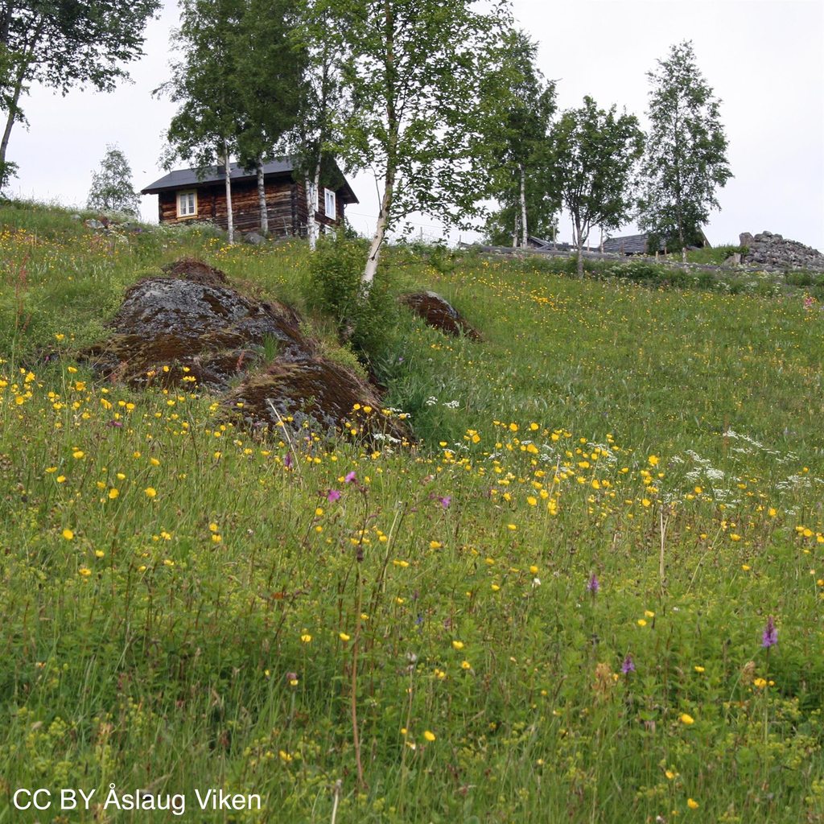

Use the MIAmaxent’s vignette for guidance or if you get stuck:

```r
vignette("a-modeling-example", package='MIAmaxent')
```

also at

https://cran.r-project.org/web/packages/MIAmaxent/vignettes/a-modeling-example.html

If you finish early, model absolute probability of presence with the presence-absence data.

Also feel free to use a different data set.